# Demo 12 | Spatial Dependence in Regression Residuals

Peter Kedron¹

2026-11-21

¹ Department of Geography, University of California Santa Barbara

Version 1.0 | First Created 2026-11-08 | Updated 2026-11-08

# 1. Introduction

Using ordinary least squares (OLS) regression to answer questions about the real world requires a researcher to make a series of assumptions about the errors of the regression model. One of these assumptions is that the errors are **independent**. In plain language, independence means knowing how far the regression model misses in one location tells us nothing about how far it misses in another location. When the errors of a regression model are independent, each observation used to fit the regression contributes a separate piece of information.

However, geographic processes rarely behave this way, and the data we use to represent those processes are rarely independent themselves. Tobler’s first law, that near things are more related than distant things, implies that neighboring places partly *repeat* each other. When a regression leaves out something that varies smoothly across space, such as a regional culture, a shared labor market, or a state’s political environment, its misses will be similar in neighboring places. The residuals will then be **spatially autocorrelated**.

The existence of spatial autocorrelation in the residuals of a regression model matters for two reasons. First, a model that treats dependent observations as independent is operating as if it has more information than it does. The standard errors of such a model are likely to be too small, its confidence intervals too narrow, and its p-values too small. Hypothesis tests on the regression coefficients will find “significant” associations that are in fact not significant too often. For a simple spatial process, the share of the sample that survives the dependence is roughly $(1-\rho)^2$, where $\rho$ measures the strength of the dependence; even a modest $\rho = 0.3$ leaves about half of the information the analyst thinks they have. Second, if the omitted spatial variable is correlated with the predictors used in the model, the coefficients of the regression will also be biased.

This demonstration checks the independence assumption for a regression of the 2024 presidential vote in the Upper Midwest. We will:

- **Define neighbors** with a spatial weights matrix, and use a guard region so that counties on the edge of the study region have complete neighbor sets.
- **Map the residuals** of the regression to see where the model over- and under-predicts.
- **Test the residuals** for spatial dependence with global and local Moran’s I, and check whether the conclusion depends on how neighbors are defined.
- **Interpret the pattern**: what it suggests the model is missing, and how much of it a measured regional effect can absorb.

The demonstration stops short of fitting spatial regression models. Its goal is to show *that* the residuals are spatially dependent, *where*, and *what kinds of process* could produce the pattern.

**Keywords:** independence assumption, residual spatial autocorrelation, spatial weights, guard region, Moran’s I, LISA

# 2. Study Region, Data, and Model

## 2.1 Study Region

The study region is the Upper Midwest: the 242 counties of Michigan, Wisconsin, and Minnesota. These **core** counties are the ones we describe and report on. Around them is a **guard region** of 39 counties in IA, IL, IN, ND, OH, SD, every county outside the three states that shares a boundary or a corner with a core county.

The **response variable** is the **Democratic share (`dem_share24`)** in the 2024 U.S. presidential election. This variable is calculated as Harris’s votes divided by the votes for Harris and Trump, times 100.

Two files are provided in this folder:

- **Upper Midwest counties (`midwest-election-2024.gpkg`):** the 281 counties of the study region, projected to NAD83 / Conus Albers (EPSG:5070, meters). The `counties` layer holds one polygon per county with its FIPS code (`fips`), state (`state_abb`), name (`county`), role (`role`: `core` or `guard`), the response variable, and the county characteristics. The `background` layer holds the surrounding U.S. states and Canadian provinces, for the maps only.
- **Codebook (`midwest-election-2024-variables.csv`):** the description, units, source, and motivating research for every variable in the `counties` layer.

The data are a regional extract of a national county-level file that joins 2024 presidential election results, compiled from the MIT Election Data and Science Lab, to county characteristics from federal and research sources, about half of them from the American Community Survey (2019–2023).

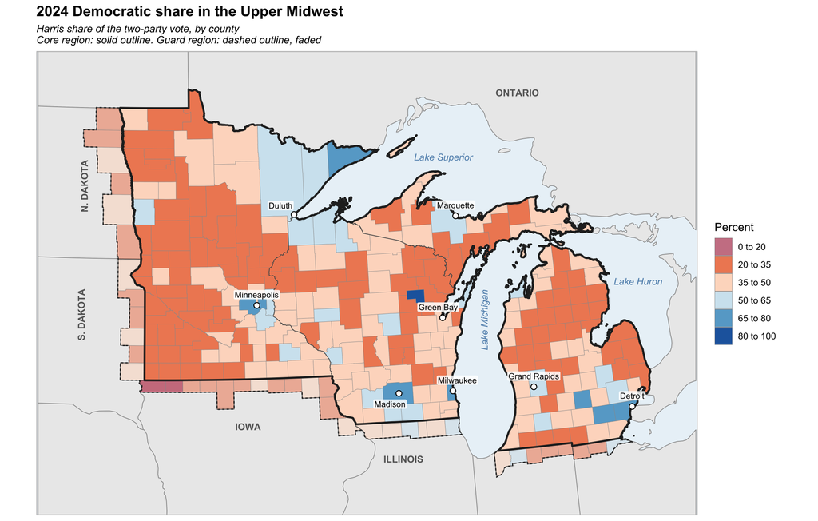

```r
# Load the county polygons (core and guard), the background layer, and the codebook
study_area <- st_read(data_file, layer = "counties", quiet = TRUE) %>%
  mutate(name = paste0(county, ", ", state_abb),
         role = factor(role, levels = c("core", "guard"))) %>%
  arrange(role, fips)
background <- st_read(data_file, layer = "background", quiet = TRUE)
codebook <- read.csv(file.path(data_dir, "midwest-election-2024-variables.csv"))

# Name the rows by FIPS code so the spatial functions can check the county order (spChk = TRUE)
rownames(study_area) <- study_area$fips

# The core study region
midwest <- study_area %>% filter(role == "core")
rownames(midwest) <- midwest$fips
```

Figure 1: The response variable, the 2024 Democratic share of the two-party vote, by county. The 242 core counties are inside the solid outline; the 39 guard counties are faded, inside the dashed outline.

## 2.2 The Regression Model

The regression model relates the Democratic share to five county characteristics, each chosen to test a hypothesis about how the Upper Midwest votes (Table 1).

| Predictor | Units | Hypothesis | Expected sign |
| --- | --- | --- | --- |
| White non-college share (`white_nocollege_pct`) | % | The education divide among white voters is a central political fault line. | Negative |
| Manufacturing share (`manuf_pct`) | % | Places exposed to deindustrialization and trade competition shifted right. | Negative |
| Log population density (`log_pop_density`) | log persons/km² | The urban–rural divide is among the strongest predictors of partisanship. | Positive |
| Median age (`median_age`) | years | Older places lean Republican. | Negative |
| Unemployment change (`unemp_change`) | percentage points | Voters punish the incumbent party when the economy worsens (2020–2023). | Negative |

Table 1: The five predictors, the hypothesis behind each, and the sign expected before fitting the model.

## 2.3 Fitting the Model

We fit the model by OLS to the core counties. The other assumptions of the model (linearity, normality, and equal variance) are checked in a separate analysis and are not repeated here; this demonstration concerns only independence.

```r
# Build the formula once, from the vector of predictor names
model_formula <- reformulate(predictors, response = "dem_share24")

# OLS on the core counties
ols_core <- lm(model_formula, data = midwest, na.action = na.fail)
```

The five predictors account for 68 percent of the county-to-county variation in the Democratic share (adjusted $R^2 =$ 0.67). The white non-college share, the manufacturing share, and log population density are significant at the 0.05 level; median age and unemployment change are not. Table 2 (Section 4.1) shows the coefficients.

# 3. Defining Neighbors

Every test of spatial dependence compares each county with its **neighbors**, so the first step is to say who the neighbors are. That choice is recorded in a **spatial weights matrix** $W$, an $n \times n$ table in which the entry $w_{ij}$ describes how strongly county $j$ counts as a neighbor of county $i$. The choice of $W$ is a hypothesis about how far local influence reaches. Defining the weights is an important conceptual and statistical choice because all the clustering test run on the residuals will depend on it.

## 3.1 Queen Contiguity

For simplicity, we use **queen contiguity**: two counties are neighbors if their boundaries touch at any point, even a single corner. The weights are then **row-standardized**: each county’s neighbors share its weight equally, so each row of $W$ sums to 1. With row-standardized weights, multiplying a variable by $W$ gives, for each county, the **average value among its neighbors**. This average is called the variable’s **spatial lag**.

```r
# Queen-contiguity neighbors for the whole study area (core and guard)
nb_queen <- poly2nb(study_area, queen = TRUE, row.names = study_area$fips)

# Row-standardized weights: each county's neighbors share its weight equally
lw_queen <- nb2listw(nb_queen, style = "W")
```

Figure 2 draws the neighbor relationships as lines between county centers. Each core county has, on average, 5.6 neighbors.

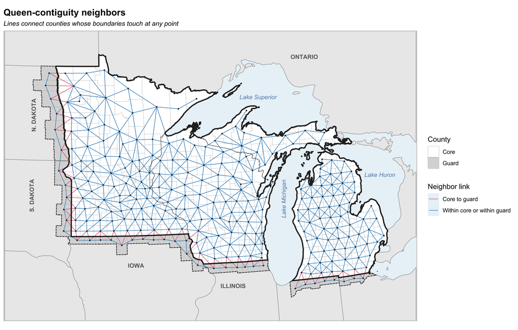

Figure 2: Queen-contiguity neighbor links for the 281 counties of the study area. Pink links connect a core county to a guard county.

## 3.2 The Guard Region

A study region cut out of a larger map has artificial edges. Without the guard region, a core county on the Iowa border would have neighbors only to the north, as if the counties across the state line did not exist. Its spatial lag would be an average over an incomplete, one-sided set of neighbors, and any test that compares it with its neighbors would be based on less information than it should be. This is an **edge effect**.

The guard region supplies the missing neighbors. Guard counties take part in every spatial calculation as neighbors, but we report results only for the core counties.

```r
# Neighbors of each core county with and without the guard region
nb_core_only <- poly2nb(midwest, queen = TRUE, row.names = midwest$fips)
gain <- tibble(fips = midwest$fips,
               without_guard = card(nb_core_only),
               with_guard = card(nb_queen)[study_area$role == "core"]) %>%
  mutate(gained = with_guard - without_guard)
```

Figure 3 shows the effect. 36 core counties gain neighbors from the guard region, an average of 2.1 each and as many as 3.

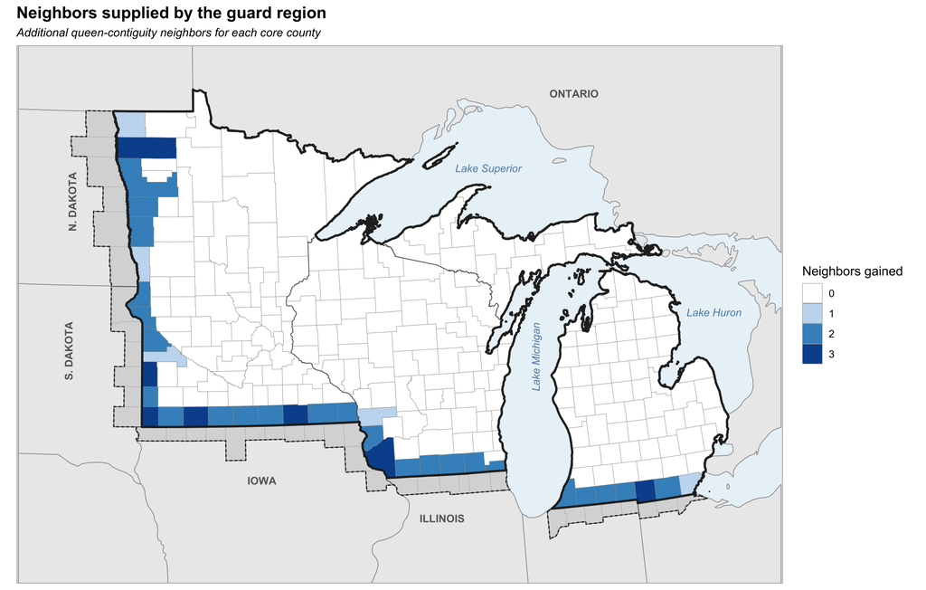

Figure 3: The number of neighbors each core county gains from the guard region. Guard counties are shown in gray.

## 3.3 What a Guard Region Cannot Fix

Two kinds of edge remain.

- **Water.** Counties on the shores of Lakes Superior, Michigan, and Huron have no neighbors across the water. This is a real edge, not an artificial one: there are no voters in the lake.
- **The Canadian border.** Counties along the border, from Lake of the Woods in Minnesota to St. Clair and Wayne in Michigan, have neighbors in Ontario that are not in the data.

Queen contiguity also creates a subtler problem. Because the Straits of Mackinac separate Michigan’s two peninsulas, the neighbor network splits into 2 separate pieces (Figure 2): Lower Michigan and the 8 Indiana and Ohio guard counties on its southern border form one, and everything else forms the other. Dependence can never pass between the two pieces. A distance-based definition, such as each county’s six nearest neighbors, would connect them; Section 5.2 checks whether that choice changes the results.

# 4. Mapping the Residuals

## 4.1 Which Residuals?

To compare each county’s residual with its neighbors’ residuals, every neighbor needs a residual, including the guard counties. We therefore refit the model to all 281 counties. The guard counties are not just extra neighbors, though; they are additional places with their own politics, so the coefficients shift (Table 2).

```r
# OLS on all counties (core and guard), so every county has a residual
ols_all <- lm(model_formula, data = study_area, na.action = na.fail)
```

| Term | Core counties only Estimate | Core counties only p | Core and guard Estimate | Core and guard p |
| --- | --- | --- | --- | --- |
| Intercept | 75.140 | < 0.001 | 69.034 | < 0.001 |
| White non-college share | -0.628 | < 0.001 | -0.597 | < 0.001 |
| Manufacturing share | -0.228 | 0.004 | -0.240 | < 0.001 |
| Log population density | 1.211 | 0.005 | 1.551 | < 0.001 |
| Median age | 0.087 | 0.319 | 0.138 | 0.092 |
| Unemployment change | -0.320 | 0.271 | -0.500 | 0.067 |

Table 2: OLS coefficients fit to the 242 core counties and to all 281 counties.

The white non-college and manufacturing coefficients barely move. The log density coefficient rises from 1.21 to 1.55, and median age and unemployment change move closer to significance. From here on, we use the residuals of the 281-county model, but we report results only for the core counties.

## 4.2 The Residual Map

A **residual** is the observed value minus the model’s prediction, $e_i = y_i - \hat{y}_i$. Here, a positive residual means a county is *more* Democratic than the model predicts; a negative residual means it is *less* Democratic. If the residuals were independent, positive and negative residuals would be scattered across the map with no pattern.

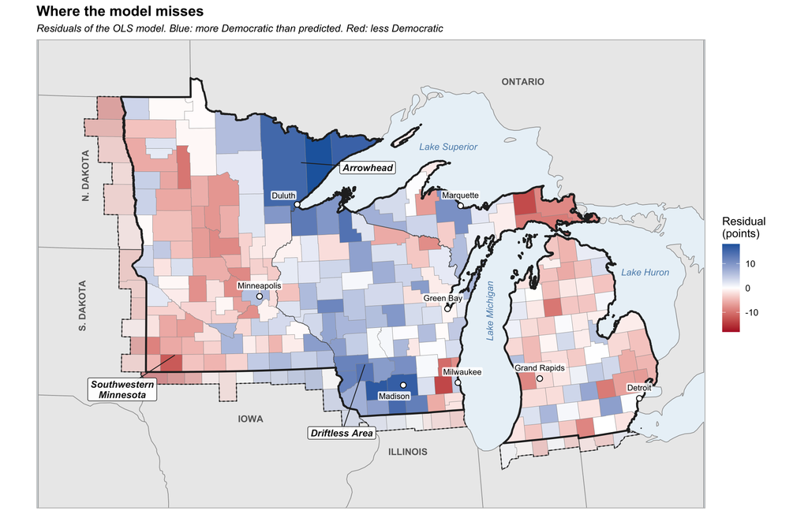

```r
study_area <- study_area %>%
  mutate(resid = residuals(ols_all),
         std_resid = rstandard(ols_all))

resid_limit <- max(abs(study_area$resid))

ggplot() +
  map_under +
  geom_sf(data = filter(study_area, role == "core"), aes(fill = resid), color = "gray60", linewidth = 0.15) +
  geom_sf(data = filter(study_area, role == "guard"), aes(fill = resid), color = "gray60", linewidth = 0.15, alpha = 0.55) +
  map_over +
  city_layers +
  region_layers +
  mw_extent +
  scale_fill_gradient2(low = resid_neg, mid = "white", high = resid_pos, midpoint = 0,
                       limits = c(-resid_limit, resid_limit), name = "Residual\n(points)") +
  labs(title = "Where the model misses",
       subtitle = "Residuals of the OLS model. Blue: more Democratic than predicted. Red: less Democratic") +
  map_theme
```

Figure 4: Residuals of the 281-county OLS model, in percentage points. Guard counties are faded. The three labeled regions are where Section 5.3 finds significant clusters of residuals.

The residuals do not appear to be randomly scattered across the study region. Blue counties cluster in southwestern Wisconsin and in Minnesota’s Arrowhead along Lake Superior, and red counties cluster in southwestern Minnesota. Wisconsin as a whole leans blue: its counties average 3.7 points more Democratic than the model predicts.

## 4.3 The Moran Scatterplot of the Residuals

We can use a **Moran scatterplot** to put the pattern on one graph. The horizontal axis is each county’s standardized residual; the vertical axis is the average standardized residual of its neighbors, its spatial lag. The slope of the line through the points equals the global Moran’s I. Most counties fall in the lower-left and upper-right quadrants. Counties the regression model under-predicts sit next to counties it under-predicts, and counties it over-predicts sit next to counties it over-predicts. This result is evidence of positive spatial autocorrelation in the residuals.

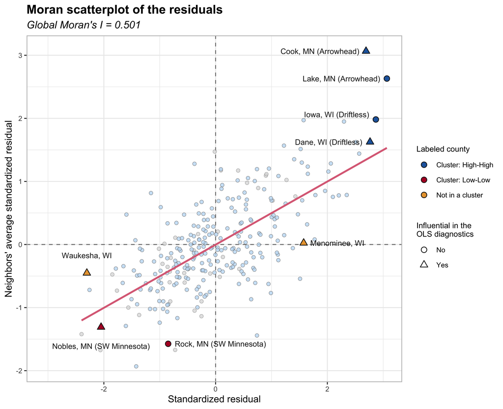

```r
# Standardize the residuals, then compute each county's neighbors' average (the spatial lag)
z <- as.numeric(scale(study_area$resid))
moran_data <- tibble(name = study_area$name, role = study_area$role, z = z, lag_z = lag.listw(lw_queen, z))
moran_slope <- coef(lm(lag_z ~ z, data = moran_data))[2]

# Counties to annotate: two from each of the three residual clusters (Section 5.3), plus two counties that
# were influential in the OLS diagnostics but sit outside the clusters. "influential" marks the five counties
# with the largest Cook's distance in the core-county model.
highlight <- tribble(
  ~name,                   ~label,                         ~group,                ~influential, ~dx,    ~dy,    ~hj,
  "Cook County, MN",       "Cook, MN (Arrowhead)",         "Cluster: High-High",  TRUE,         -0.12,  0,      1,
  "Lake County, MN",       "Lake, MN (Arrowhead)",         "Cluster: High-High",  FALSE,        -0.12,  0,      1,
  "Iowa County, WI",       "Iowa, WI (Driftless)",         "Cluster: High-High",  FALSE,        -0.12,  0.08,   1,
  "Dane County, WI",       "Dane, WI (Driftless)",         "Cluster: High-High",  TRUE,         -0.14,  0,      1,
  "Nobles County, MN",     "Nobles, MN (SW Minnesota)",    "Cluster: Low-Low",    TRUE,         0,      -0.3,   0.5,
  "Rock County, MN",       "Rock, MN (SW Minnesota)",      "Cluster: Low-Low",    FALSE,        0.12,   0,      0,
  "Menominee County, WI",  "Menominee, WI",                "Not in a cluster",    TRUE,         0.12,   0,      0,
  "Waukesha County, WI",   "Waukesha, WI",                 "Not in a cluster",    TRUE,         0,      0.28,   0.5
) %>%
  left_join(moran_data, by = "name")

highlight_fill <- c(`Cluster: High-High` = resid_pos, `Cluster: Low-Low` = resid_neg, `Not in a cluster` = "#E8A33D")

ggplot(moran_data, aes(z, lag_z)) +
  geom_hline(yintercept = 0, color = "gray50", linetype = "dashed") +
  geom_vline(xintercept = 0, color = "gray50", linetype = "dashed") +
  geom_point(data = filter(moran_data, role == "guard"), shape = 21, fill = "gray85", color = "gray55", size = 1.8, stroke = 0.3, alpha = 0.7) +
  geom_point(data = filter(moran_data, role == "core"), shape = 21, fill = "#C1DDF4", color = "gray45", size = 1.8, stroke = 0.3, alpha = 0.8) +
  geom_smooth(method = "lm", formula = y ~ x, se = FALSE, color = "#DC6D85", linewidth = 1) +
  geom_point(data = highlight, aes(fill = group, shape = influential), color = "gray10", size = 2.6, stroke = 0.6) +
  geom_text(data = highlight, aes(x = z + dx, y = lag_z + dy, label = label, hjust = hj), size = 3.1, color = "gray10") +
  scale_fill_manual(values = highlight_fill, name = "Labeled county") +
  scale_shape_manual(values = c(`FALSE` = 21, `TRUE` = 24), labels = c("No", "Yes"),
                     name = "Influential in the\nOLS diagnostics") +
  guides(fill = guide_legend(override.aes = list(shape = 21, size = 2.6), order = 1),
         shape = guide_legend(override.aes = list(fill = "white", size = 2.6), order = 2)) +
  scale_x_continuous(expand = expansion(mult = c(0.18, 0.05))) +
  labs(title = "Moran scatterplot of the residuals",
       subtitle = sprintf("Global Moran's I = %.3f", moran_slope),
       x = "Standardized residual", y = "Neighbors' average standardized residual") +
  themeGrid + theme(legend.position = "right", legend.title = element_text(size = 9), legend.text = element_text(size = 8))
```

Figure 5: Each county’s standardized residual against the average standardized residual of its queen-contiguity neighbors. The slope of the pink line is Moran’s I. Core counties are light blue and guard counties gray. Labeled counties include two from each of the residual clusters mapped in Section 5.3 and two counties outside them; triangles mark counties that were among the most influential (largest Cook’s distance) in the OLS diagnostics.

# 5. Testing for Spatial Dependence

## 5.1 Global Moran’s I

Figures 4 and 5 help to visualize potential spatial patterning in the residuals and offer a descriptive statistical summary of the relationship among residuals across space. However, these figure do not include a formal statistical significance test of that pattern. Such a test can be conducted using **Moran’s I**, which tests the residuals $e_i$ against a null hypothesis of complete spatial randomness.

However, Testing Moran’s I on regression residuals needs one adjustment. Unlike other variables, residuals are not free to vary independently. The residuals of a regression model must sum to zero and be uncorrelated with every predictor. That constraint shifts the value of I expected when there is no spatial dependence away from the usual $-1/(n-1)$. `lm.morantest()` takes the fitted model itself and calculates the expected value and variance of I under these constraints.

```r
# Moran's I of the OLS residuals, with expectation and variance adjusted for the model's predictors
moran_resid <- lm.morantest(ols_all, lw_queen, alternative = "two.sided", spChk = TRUE)
moran_resid
```

```
##
##  Global Moran I for regression residuals
##
## data:
## model: lm(formula = model_formula, data = study_area, na.action =
## na.fail)
## weights: lw_queen
##
## Moran I statistic standard deviate = 13.829, p-value <
## 0.00000000000000022
## alternative hypothesis: two.sided
## sample estimates:
## Observed Moran I      Expectation         Variance
##      0.500538088     -0.011205053      0.001369316
```

Running this test, we can see that the residuals have a Moran’s I of 0.501, compared with an expected value of -0.011 if they were independent (z = 13.8, $p$ < 0.001). The independence assumption fails. A **permutation test** reaches the same conclusion without relying on a normal approximation.

```r
# 9,999 random shuffles of the residuals across the map
set.seed(172)
moran_perm <- moran.mc(residuals(ols_all), lw_queen, nsim = 9999)
```

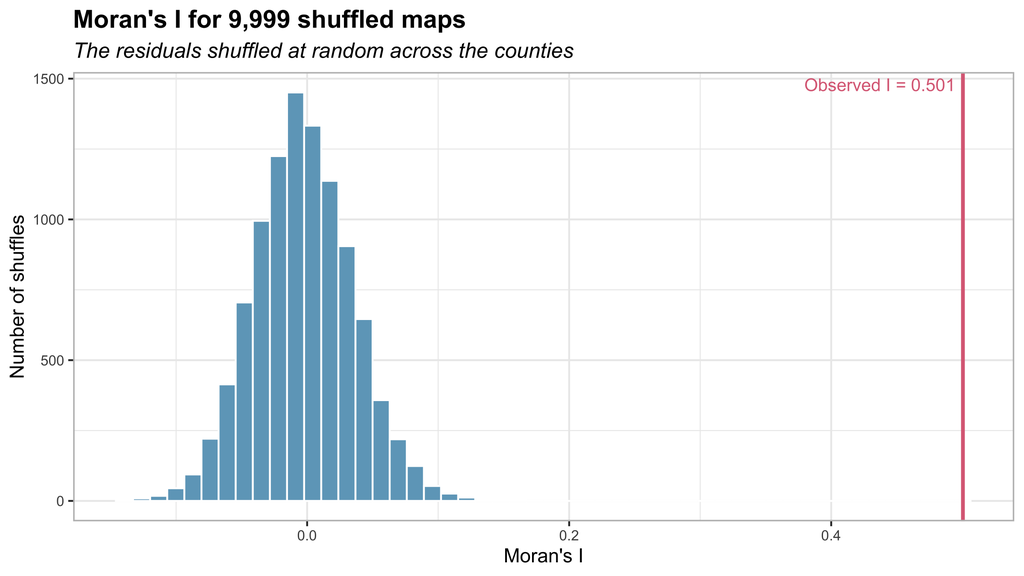

```r
perm_I <- head(moran_perm$res, -1)   # the shuffled values; the last element is the observed I

ggplot(tibble(I = perm_I), aes(I)) +
  geom_histogram(bins = 50, fill = "#6EA6C3", color = "white") +
  geom_vline(xintercept = moran_perm$statistic, color = "#DC6D85", linewidth = 1) +
  annotate("text", x = moran_perm$statistic, y = Inf, label = sprintf("Observed I = %.3f", moran_perm$statistic),
           hjust = 1.05, vjust = 1.5, color = "#DC6D85", size = 3.5) +
  labs(title = "Moran's I for 9,999 shuffled maps",
       subtitle = "The residuals shuffled at random across the counties",
       x = "Moran's I", y = "Number of shuffles") +
  themeGrid
```

Figure 6: The distribution of Moran’s I across 9,999 random shuffles of the residuals, with the observed value marked.

The largest Moran’s I among the 9,999 shuffled maps is 0.158, far below the observed 0.501. None of the shuffles comes close, so the pseudo p-value is the smallest possible with 9,999 permutations, 0.0001.

## 5.2 Does the Choice of Neighbors Matter?

Because every result depends on $W$, it is worth checking that the conclusion does not hinge on one definition of neighbors. Table 3 repeats the test with two alternatives: queen contiguity without the guard region, and each county’s six nearest neighbors (measured between points inside each county), which connects Lower Michigan to the rest of the region.

```r
# (a) Queen contiguity, core counties only, residuals of the core-only model
lw_core_only <- nb2listw(nb_core_only, style = "W")

# (b) Six nearest neighbors, core and guard
coords <- st_coordinates(st_point_on_surface(st_geometry(study_area)))
nb_k6 <- knn2nb(knearneigh(coords, k = 6), row.names = study_area$fips)
lw_k6 <- nb2listw(nb_k6, style = "W")

sensitivity <- list(
  "Queen, core and guard" = lm.morantest(ols_all, lw_queen, spChk = TRUE),
  "Queen, core only (no guard)" = lm.morantest(ols_core, lw_core_only, spChk = TRUE),
  "Six nearest neighbors, core and guard" = lm.morantest(ols_all, lw_k6, spChk = TRUE))
```

| Neighbors | Counties | Moran’s I | Expected | z | p |
| --- | --- | --- | --- | --- | --- |
| Queen, core and guard | 281 | 0.501 | -0.011 | 13.829 | < 0.001 |
| Queen, core only (no guard) | 242 | 0.499 | -0.013 | 12.766 | < 0.001 |
| Six nearest neighbors, core and guard | 281 | 0.459 | -0.011 | 14.762 | < 0.001 |

Table 3: Moran’s I of the OLS residuals under three definitions of neighbors.

Moran’s I ranges from 0.46 to 0.50 across the three definitions, and every test rejects independence decisively. The guard region barely changes the global statistic, because it affects only the 36 border counties. Its value is local: it makes the results for those border counties trustworthy, which matters for the local statistics that follow.

## 5.3 Local Moran’s I

Global Moran’s I tells us *that* the residuals are not randomly distributed across space. We can use **Local Moran’s I** to investigate *where* clusters of high and low residuals exist. That information can be helpful in diagnosing what our regression model may be missing. For each county, it compares the county’s standardized residual with its neighbors’ standardized residuals.

We test each county with a conditional permutation test, holding its own residual fixed and shuffling the others, and correct for running one test per county with the false discovery rate (FDR). Results are reported for the core counties only.

```r
# Local Moran's I with 9,999 conditional permutations
lisa <- localmoran_perm(residuals(ols_all), lw_queen, nsim = 9999,
                        no_repeat_in_row = TRUE, iseed = 172)

# Adjust the p-values for multiple testing, then classify each county
study_area <- study_area %>%
  mutate(p_sim = lisa[, "Pr(z != E(Ii)) Sim"],
         p_fdr = p.adjust(p_sim, method = "fdr"),
         quadrant = attr(lisa, "quadr")$mean,
         cluster = ifelse(p_fdr < 0.05, as.character(quadrant), "Not significant"))
```

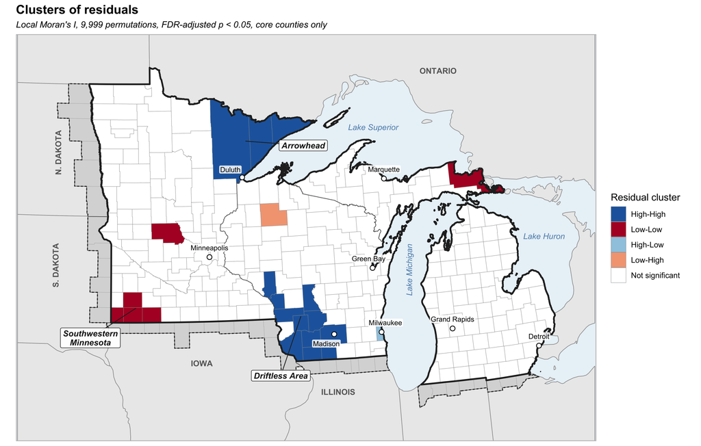

```r
cluster_colors <- c(`High-High` = resid_pos, `Low-Low` = resid_neg,
                    `High-Low` = "#9ecae1", `Low-High` = "#f4a582", `Not significant` = "white")
lisa_core <- filter(study_area, role == "core") %>%
  mutate(cluster = factor(cluster, levels = names(cluster_colors)))

ggplot() +
  map_under +
  geom_sf(data = filter(study_area, role == "guard"), fill = "gray85", color = "gray70", linewidth = 0.15) +
  geom_sf(data = lisa_core, aes(fill = cluster), color = "gray60", linewidth = 0.15) +
  map_over +
  city_layers +
  region_layers +
  mw_extent +
  scale_fill_manual(values = cluster_colors, drop = FALSE, name = "Residual cluster") +
  labs(title = "Clusters of residuals",
       subtitle = "Local Moran's I, 9,999 permutations, FDR-adjusted p < 0.05, core counties only") +
  map_theme
```

Figure 7: Significant clusters of OLS residuals among the core counties. High–High: counties more Democratic than predicted, next to counties that are also more Democratic than predicted. Low–Low: the reverse. Guard counties are shown in gray. The three main clusters are labeled.

| Cluster | County | Democratic share | Residual | FDR p |
| --- | --- | --- | --- | --- |
| High-High | Lake County, MN | 52.0 | 18.0 | 0.019 |
| High-High | Iowa County, WI | 53.9 | 16.9 | 0.016 |
| High-High | Dane County, WI | 76.2 | 16.3 | 0.009 |
| High-High | Cook County, MN | 67.9 | 15.8 | 0.037 |
| High-High | St. Louis County, MN | 57.0 | 15.1 | 0.026 |
| High-High | Green County, WI | 50.1 | 14.8 | 0.024 |
| High-High | Richland County, WI | 43.4 | 13.5 | 0.009 |
| High-High | Vernon County, WI | 46.0 | 11.9 | 0.034 |
| High-High | Sauk County, WI | 49.2 | 9.3 | 0.009 |
| High-High | La Crosse County, WI | 54.7 | 9.1 | 0.026 |
| High-High | Lafayette County, WI | 39.8 | 9.0 | 0.026 |
| High-High | Trempealeau County, WI | 39.2 | 8.3 | 0.043 |
| High-High | Grant County, WI | 40.8 | 7.2 | 0.019 |
| High-High | Juneau County, WI | 33.8 | 0.6 | 0.037 |
| Low-Low | Jackson County, MN | 28.6 | -4.0 | 0.024 |
| Low-Low | Rock County, MN | 30.0 | -5.0 | 0.009 |
| Low-Low | Stearns County, MN | 36.4 | -5.5 | 0.038 |
| Low-Low | Murray County, MN | 28.4 | -5.9 | 0.030 |
| Low-Low | Chippewa County, MI | 37.7 | -8.4 | 0.037 |
| Low-Low | Nobles County, MN | 31.9 | -12.1 | 0.009 |
| High-Low | Milwaukee County, WI | 69.6 | 4.4 | 0.030 |
| Low-High | Sawyer County, WI | 41.7 | -2.2 | 0.024 |

Table 4: The core counties in significant residual clusters, ordered by cluster type and residual.

14 core counties form High–High clusters and 6 form Low–Low clusters. The High–High counties fall in two groups: 11 in southern and western Wisconsin (Dane, Grant, Green, Iowa, Juneau, La Crosse, Lafayette, Richland, Sauk, Trempealeau, and Vernon) and 3 in Minnesota’s Arrowhead (Cook, Lake, and St. Louis). The Low–Low counties are mostly in southwestern and central Minnesota (Jackson, Murray, Nobles, Rock, and Stearns), along with Chippewa County, MI.

# 6. What the Pattern Suggests

## 6.1 Reading the Clusters

Spatially clustered residuals mean the model is missing something that varies smoothly across the region. The clusters suggest what.

- **Southwestern Wisconsin.** Most of the Wisconsin High–High counties lie in or near the Driftless Area, a rural region west of Madison with a long history of voting more Democratic than similar rural places elsewhere. Education, industry, density, age, and the economy do not capture that history.
- **The Arrowhead.** The Minnesota High–High counties along Lake Superior share a history of mining, unions, and Democratic–Farmer–Labor politics that the five predictors do not measure.
- **Southwestern Minnesota.** The Low–Low counties are agricultural counties that vote even more Republican than their education and density predict.

Each of these is a *regional* story: something shared by a group of neighboring counties. That is exactly the kind of omission that produces spatially autocorrelated residuals.

## 6.2 Is Part of It a State Effect?

One regional factor we *can* measure is the state. States differ in election law, campaign spending, candidates down the ballot, and political culture, and those differences are shared by every county in the state. Figure 8 shows that the residuals differ by state.

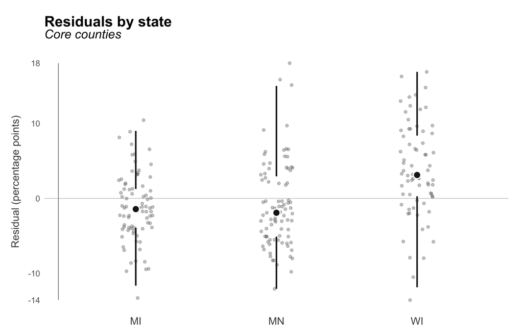

```r
# A Tufte-style box plot drawn over each state's points: a dot at the median, whiskers from the box edges outward,
# and a gap where the box would be
state_resid <- study_area %>% st_drop_geometry() %>% filter(role == "core") %>%
  mutate(state_abb = factor(state_abb))
state_box <- state_resid %>%
  group_by(state_abb) %>%
  summarise(q1 = quantile(resid, 0.25), med = median(resid), q3 = quantile(resid, 0.75),
            lo = max(min(resid), q1 - 1.5 * (q3 - q1)), hi = min(max(resid), q3 + 1.5 * (q3 - q1)),
            .groups = "drop") %>%
  mutate(x = as.numeric(state_abb))

# Range frame: the y axis spans only the range of the residuals
y_range <- range(state_resid$resid)
y_breaks <- c(y_range[1], -10, 0, 10, y_range[2])

ggplot() +
  geom_hline(yintercept = 0, color = "gray80", linewidth = 0.3) +
  geom_jitter(data = state_resid, aes(as.numeric(state_abb), resid), width = 0.12, height = 0,
              size = 1, alpha = 0.35, color = "gray40") +
  geom_segment(data = state_box, aes(x = x, xend = x, y = lo, yend = q1), color = "gray10", linewidth = 0.7) +
  geom_segment(data = state_box, aes(x = x, xend = x, y = q3, yend = hi), color = "gray10", linewidth = 0.7) +
  geom_point(data = state_box, aes(x, med), shape = 21, size = 2.8, fill = "gray10", color = "white", stroke = 0.8) +
  annotate("segment", x = 0.45, xend = 0.45, y = y_range[1], yend = y_range[2], color = "gray50", linewidth = 0.3) +
  scale_x_continuous(breaks = state_box$x, labels = levels(state_resid$state_abb), expand = expansion(add = c(0.1, 0.3))) +
  scale_y_continuous(breaks = y_breaks, labels = function(v) formatC(v, format = "f", digits = 0)) +
  coord_cartesian(xlim = c(0.45, max(state_box$x) + 0.35), clip = "off") +
  labs(title = "Residuals by state", subtitle = "Core counties",
       x = NULL, y = "Residual (percentage points)") +
  theme_void() +
  theme(plot.title = element_text(size = 14, face = "bold"),
        plot.subtitle = element_text(size = 12, face = "italic", margin = margin(b = 10)),
        axis.text.x = element_text(size = 10, color = "gray30", margin = margin(t = 4)),
        axis.text.y = element_text(size = 8, color = "gray40", hjust = 1, margin = margin(r = 4)),
        axis.title.y = element_text(size = 10, color = "gray30", angle = 90, margin = margin(r = 8)),
        plot.margin = margin(10, 14, 10, 10))
```

Figure 8: OLS residuals of the core counties by state. Each county is a gray point; drawn over them, the black dot marks the state’s median residual, and the lines extend from the lower and upper quartiles to the most extreme residuals within 1.5 times the interquartile range.

A simple way to absorb a state effect is to add a **dummy variable** for each state, which lets each state have its own intercept. We use Minnesota as the reference state, so each state’s coefficient is its average difference from Minnesota, holding the five predictors constant. If the state effect explained the spatial pattern, the residuals of this model would no longer be spatially autocorrelated.

```r
# Add a dummy variable for each state, with Minnesota as the reference
study_area <- study_area %>% mutate(state_f = relevel(factor(state_abb), ref = "MN"))
ols_state <- lm(update(model_formula, . ~ . + state_f), data = study_area, na.action = na.fail)

moran_state <- lm.morantest(ols_state, lw_queen, alternative = "two.sided", spChk = TRUE)
```

With state dummies, Wisconsin counties average 5.9 points more Democratic than comparable Minnesota counties, and Michigan counties 0.9 points more, and the model’s $R^2$ rises from 0.68 to 0.74. The residual Moran’s I falls from 0.501 to 0.406, but remains highly significant ($p$ < 0.001).

The state-level variable absorbs part of the spatial dependence, but most of the spatial dependence remains. The clusters in Figure 7 are much smaller than states: the Driftless Area is only part of Wisconsin, and the Arrowhead only part of Minnesota, so a single intercept for each state cannot capture them.

## 6.3 Two Stories for the Same Map

The remaining dependence could come from two quite different processes.

**Spillovers between neighbors.** The vote in one county may itself influence the vote in neighboring counties, through shared media markets, social networks, commuting, or campaign organizing that crosses county lines. In that case a county’s outcome depends on its neighbors’ outcomes:
$$y = \rho W y + X\beta + \varepsilon$$
where $Wy$ is the neighbors’ average Democratic share and $\rho$ measures the strength of the spillover. This is a **spatial lag** model.

**Shared unmeasured influences.** Alternatively, neighboring counties may simply share something the model leaves out, such as the history of the Driftless Area or the labor politics of the Arrowhead, without influencing one another at all. In that case the dependence lives in the errors:
$$y = X\beta + u, \qquad u = \lambda W u + \varepsilon$$
where $\lambda$ measures how strongly the unexplained part of the vote is shared among neighbors. This is a **spatial error** model.

Unadjusted for, both processes produce residuals that cluster on the map. Therefore, the residual map cannot be used by itself to tell one process from the other. Choosing between these alternative models takes theory about how the vote is produced, and diagnostic tests designed to distinguish the two forms of dependence. Estimating these models is the next step beyond this demonstration.

# 7. Summary

- OLS assumes independent errors. For geographic data, that assumption should be checked, not assumed, because ignoring dependence makes the model overconfident and can bias its coefficients.
- Checking it starts with a definition of neighbors. A guard region gives counties on the edge of the study region complete neighbor sets, but cannot fix real edges such as lake shores, or missing data across an international border.
- The residuals of the Upper Midwest model are strongly spatially autocorrelated (Moran’s I = 0.50), under every definition of neighbors we tried.
- Local Moran’s I locates the dependence in southwestern Wisconsin, the Arrowhead, and southwestern Minnesota: regions with shared histories that the predictors do not measure.
- State dummies absorb part of the pattern, but most of it remains. Spatial regression models offer two ways to represent what is left: spillovers between neighbors, or shared unmeasured influences.

**Considerations**

1. Section 3.3 noted that queen contiguity splits the region into two pieces at the Straits of Mackinac. Which of the two would you expect to matter more for the results in Section 5.3: the missing link across the Straits, or the missing Ontario neighbors? Why?
2. Choose one of the clusters in Figure 7. Propose a variable, in the data or not, that might explain it, and explain whether adding it would be more consistent with the spillover story or the shared-influence story in Section 6.3.
3. The guard region barely changed the global Moran’s I (Table 3). Why might it still matter for the local results in Figure 7?

### Declaration of Generative AI and AI-Assisted Technologies

The author used Anthropic’s Claude (Opus 5.5) when developing this demonstration. A connection to RStudio through the ClaudeR package was used to draft and debug the R code. The author subsequently reviewed and edited all of that output and takes full responsibility for the content.